# Time walking

### 2.9.2 Wave 2

#### 2.9.2.1 Study-specific variable description

| **Name** | `f_PWALKANY` |
| --- | --- |
| **Label** | `walk of 0.5 kilometre in last month?` |
| **Table name** | `1066-UrbanMexico-Followup` |
| **Categories:** | `0 = No` `1 = Yes` |
| **Missings:** | `NA` |
| **Description** |  |

f_PWALKANY

| Sample size | Missing values |
| --- | --- |
| 749 | 3 |

Category

|  | 0 | 1 |
| --- | --- | --- |
| Frequency | 308.00 | 438.00 |
| Percentage | 41.12 | 58.48 |

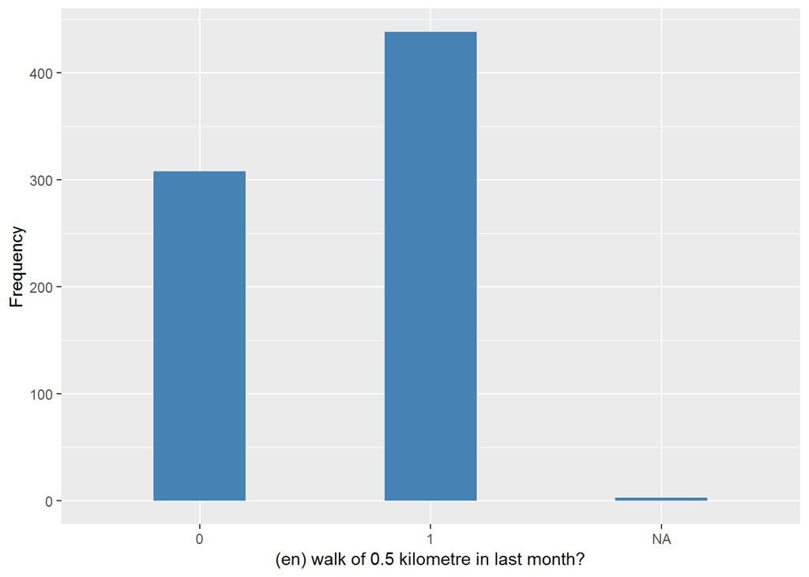

#### 2.9.2.2 Harmonisation algorithm

To compute the harmonize variable from the study-specific variable it has to be recoded as follows:

- `NA into 999`

```r
t1066_ds_UM_w2 <- tibble(id = t1066_UM_w2$id)
t1066_ds_UM_w2$t_walks <- Recode(t1066_UM_w2$f_PWALKANY, "NA = '999' ")
t1066_ds_UM_w2$t_walks <- labelled(t1066_ds_UM_w2$t_walks, labels = c(Missing = 999,
    Do_not_know = 998, Refuse = 997, Not_applicable = 996, Does_not_answer = 995,
    Not_attempt_not_done = 994, Disable_to_measure = 993, Impute = 992, CAPI_interviewer_error = 991))
```

#### 2.9.2.3 Statistical description of the new harmonised variable

Walking at least 10 min or equivalent by 0.5km during the last 1-2 weeks

| Sample size | Missing values |
| --- | --- |
| 749 | 3 |

Category

|  | 0 | 1 |
| --- | --- | --- |
| Frequency | 308.00 | 438.00 |
| Percentage | 41.12 | 58.48 |

Type of missing

|  | 991 | 992 | 993 | 994 | 995 | 996 | 997 | 998 | 999 | NA |
| --- | --- | --- | --- | --- | --- | --- | --- | --- | --- | --- |
| Frequency | 0 | 0 | 0 | 0 | 0 | 0 | 0 | 0 | 3.0 | 0 |
| Percentage | 0 | 0 | 0 | 0 | 0 | 0 | 0 | 0 | 0.4 | 0 |

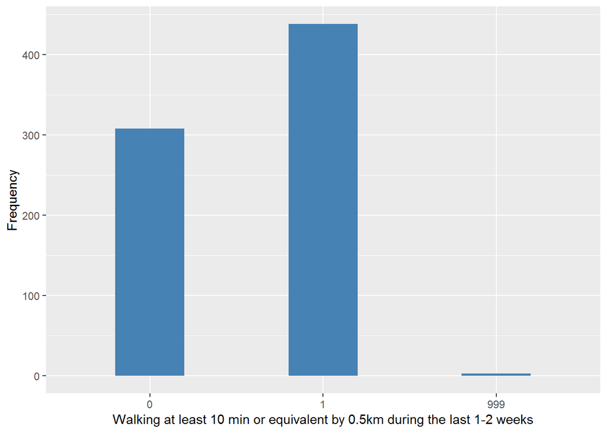

#### 2.9.2.4 Validation

|  | 0->0 | 1->1 | NA->999 |
| --- | --- | --- | --- |
| BeforeH | 308 | 438 | 3 |
| AfterH | 308 | 438 | 3 |

## 2.10 Rural Mexico

### 2.10.1 Wave 1

#### 2.10.1.1 Study-specific variable description

| **Name** | `PWALKANY` |
| --- | --- |
| **Label** | `walk of 0.5 kilometre in last month?` |
| **Table name** | `1066-RuralMexico-Baseline` |
| **Categories:** | `0 = No` `1 = Yes` |
| **Missings:** | `NA` |
| **Description** |  |

PWALKANY

| Sample size | Missing values |
| --- | --- |
| 1000 | 16 |

Category

|  | 0 | 1 |
| --- | --- | --- |
| Frequency | 350 | 634.0 |
| Percentage | 35 | 63.4 |

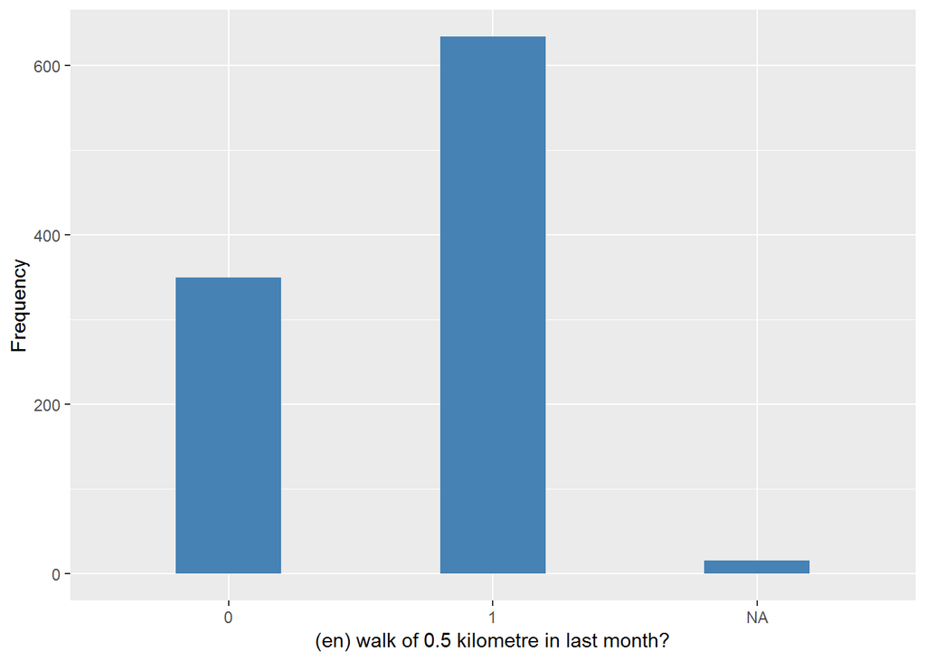

#### 2.10.1.2 Harmonisation algorithm

To compute the harmonize variable from the study-specific variable it has to be recoded as follows:

- `NA into 999`

```r
t1066_ds_RM_w1 <- tibble(id = t1066_RM_w1$id)
t1066_ds_RM_w1$t_walks <- Recode(t1066_RM_w1$PWALKANY, "NA = '999' ")
t1066_ds_RM_w1$t_walks <- labelled(t1066_ds_RM_w1$t_walks, labels = c(Missing = 999,
    Do_not_know = 998, Refuse = 997, Not_applicable = 996, Does_not_answer = 995,
    Not_attempt_not_done = 994, Disable_to_measure = 993, Impute = 992, CAPI_interviewer_error = 991))
```

#### 2.10.1.3 Statistical description of the new harmonised variable

Walking at least 10 min or equivalent by 0.5km during the last 1-2 weeks

| Sample size | Missing values |
| --- | --- |
| 1000 | 16 |

Category

|  | 0 | 1 |
| --- | --- | --- |
| Frequency | 350 | 634.0 |
| Percentage | 35 | 63.4 |

Type of missing

|  | 991 | 992 | 993 | 994 | 995 | 996 | 997 | 998 | 999 | NA |
| --- | --- | --- | --- | --- | --- | --- | --- | --- | --- | --- |
| Frequency | 0 | 0 | 0 | 0 | 0 | 0 | 0 | 0 | 16.0 | 0 |
| Percentage | 0 | 0 | 0 | 0 | 0 | 0 | 0 | 0 | 1.6 | 0 |

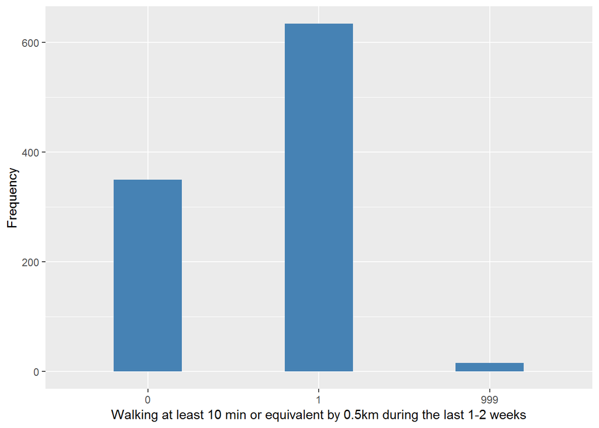

#### 2.10.1.4 Validation

|  | 0->0 | 1->1 | NA->999 |
| --- | --- | --- | --- |
| BeforeH | 350 | 634 | 16 |
| AfterH | 350 | 634 | 16 |

### 2.10.2 Wave 2

#### 2.10.2.1 Study-specific variable description

| **Name** | `f_PWALKANY` |
| --- | --- |
| **Label** | `walk of 0.5 kilometre in last month?` |
| **Table name** | `1066-RuralMexico-Followup` |
| **Categories:** | `0 = No` `1 = Yes` |
| **Missings:** | `NA` |
| **Description** |  |

f_PWALKANY

| Sample size | Missing values |
| --- | --- |
| 713 | 3 |

Category

|  | 0 | 1 |
| --- | --- | --- |
| Frequency | 270.00 | 440.00 |
| Percentage | 37.87 | 61.71 |

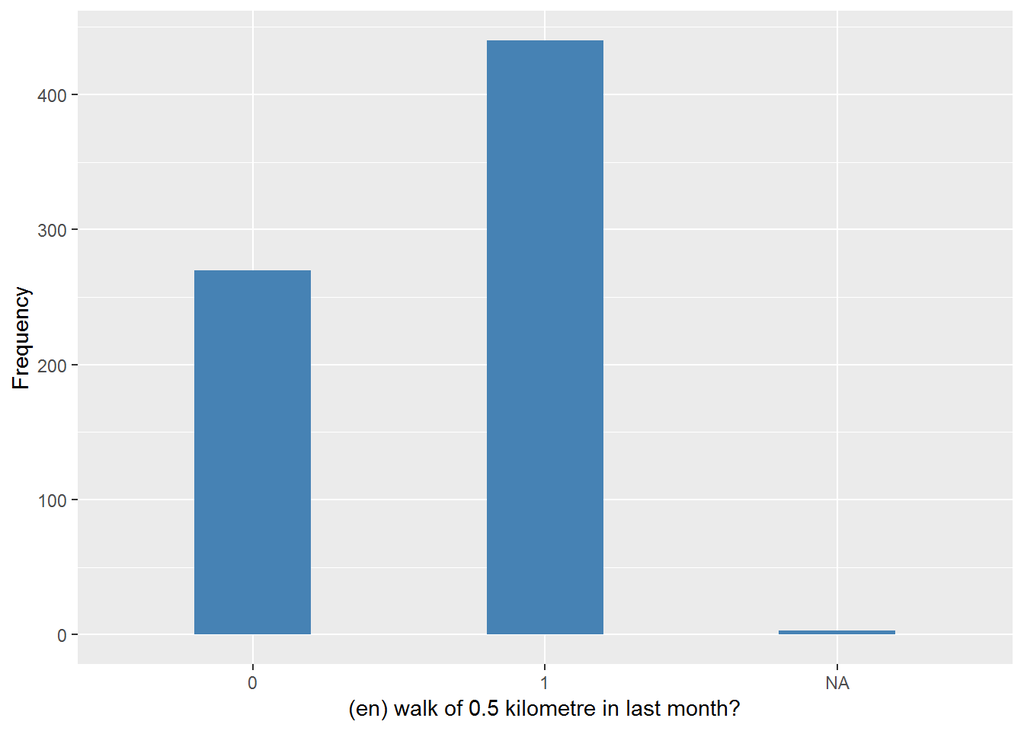

#### 2.10.2.2 Harmonisation algorithm

To compute the harmonize variable from the study-specific variable it has to be recoded as follows:

- `NA into 999`

```r
t1066_ds_RM_w2 <- tibble(id = t1066_RM_w2$id)
t1066_ds_RM_w2$t_walks <- Recode(t1066_RM_w2$f_PWALKANY, "NA = '999' ")
t1066_ds_RM_w2$t_walks <- labelled(t1066_ds_RM_w2$t_walks, labels = c(Missing = 999,
    Do_not_know = 998, Refuse = 997, Not_applicable = 996, Does_not_answer = 995,
    Not_attempt_not_done = 994, Disable_to_measure = 993, Impute = 992, CAPI_interviewer_error = 991))
```

#### 2.10.2.3 Statistical description of the new harmonised variable

Walking at least 10 min or equivalent by 0.5km during the last 1-2 weeks

| Sample size | Missing values |
| --- | --- |
| 713 | 3 |

Category

|  | 0 | 1 |
| --- | --- | --- |
| Frequency | 270.00 | 440.00 |
| Percentage | 37.87 | 61.71 |

Type of missing

|  | 991 | 992 | 993 | 994 | 995 | 996 | 997 | 998 | 999 | NA |
| --- | --- | --- | --- | --- | --- | --- | --- | --- | --- | --- |
| Frequency | 0 | 0 | 0 | 0 | 0 | 0 | 0 | 0 | 3.00 | 0 |
| Percentage | 0 | 0 | 0 | 0 | 0 | 0 | 0 | 0 | 0.42 | 0 |

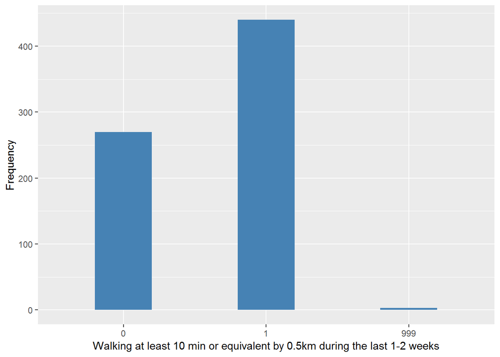

#### 2.10.2.4 Validation

|  | 0->0 | 1->1 | NA->999 |
| --- | --- | --- | --- |
| BeforeH | 270 | 440 | 3 |
| AfterH | 270 | 440 | 3 |

## 2.11 Puerto Rico

### 2.11.1 Wave 1

#### 2.11.1.1 Study-specific variable description

| **Name** | `PWALKANY` |
| --- | --- |
| **Label** | `walk of 0.5 kilometre in last month?` |
| **Table name** | `1066-PuertoRico-Baseline` |
| **Categories:** | `0 = No` `1 = Yes` |
| **Missings:** | `NA` |
| **Description** |  |

PWALKANY

| Sample size | Missing values |
| --- | --- |
| 2009 | 9 |

Category

|  | 0 | 1 |
| --- | --- | --- |
| Frequency | 1351.00 | 649.0 |
| Percentage | 67.25 | 32.3 |

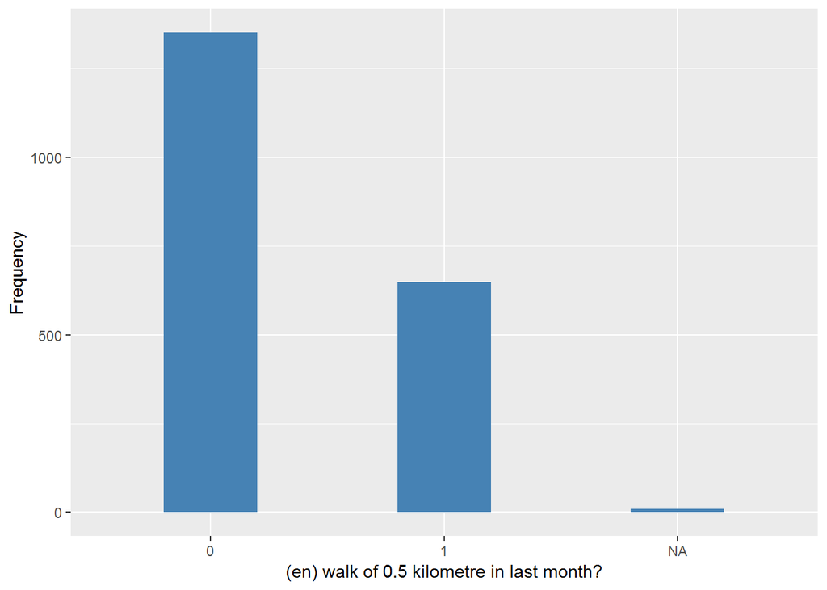

#### 2.11.1.2 Harmonisation algorithm

To compute the harmonize variable from the study-specific variable it has to be recoded as follows:

- `NA into 999`

```r
t1066_ds_PR_w1 <- tibble(id = t1066_PR_w1$id)
t1066_ds_PR_w1$t_walks <- Recode(t1066_PR_w1$PWALKANY, "NA = '999' ")
t1066_ds_PR_w1$t_walks <- labelled(t1066_ds_PR_w1$t_walks, labels = c(Missing = 999,
    Do_not_know = 998, Refuse = 997, Not_applicable = 996, Does_not_answer = 995,
    Not_attempt_not_done = 994, Disable_to_measure = 993, Impute = 992, CAPI_interviewer_error = 991))
```

#### 2.11.1.3 Statistical description of the new harmonised variable

Walking at least 10 min or equivalent by 0.5km during the last 1-2 weeks

| Sample size | Missing values |
| --- | --- |
| 2009 | 9 |

Category

|  | 0 | 1 |
| --- | --- | --- |
| Frequency | 1351.00 | 649.0 |
| Percentage | 67.25 | 32.3 |

Type of missing

|  | 991 | 992 | 993 | 994 | 995 | 996 | 997 | 998 | 999 | NA |
| --- | --- | --- | --- | --- | --- | --- | --- | --- | --- | --- |
| Frequency | 0 | 0 | 0 | 0 | 0 | 0 | 0 | 0 | 9.00 | 0 |
| Percentage | 0 | 0 | 0 | 0 | 0 | 0 | 0 | 0 | 0.45 | 0 |

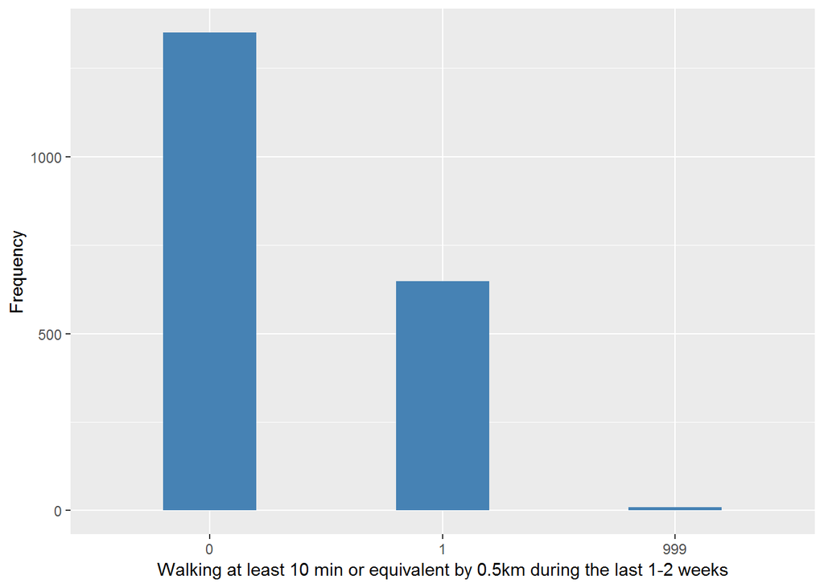

#### 2.11.1.4 Validation

|  | 0->0 | 1->1 | NA->999 |
| --- | --- | --- | --- |
| BeforeH | 1351 | 649 | 9 |
| AfterH | 1351 | 649 | 9 |

### 2.11.2 Wave 2

#### 2.11.2.1 Study-specific variable description

| **Name** | `f_PWALKANY` |
| --- | --- |
| **Label** | `walk of 0.5 kilometre in last month?` |
| **Table name** | `1066-PuertoRico-Followup` |
| **Categories:** | `0 = No` `1 = Yes` |
| **Missings:** | `NA` |
| **Description** |  |

f_PWALKANY

| Sample size | Missing values |
| --- | --- |
| 1265 | 12 |

Category

|  | 0 | 1 |
| --- | --- | --- |
| Frequency | 1001.00 | 252.00 |
| Percentage | 79.13 | 19.92 |

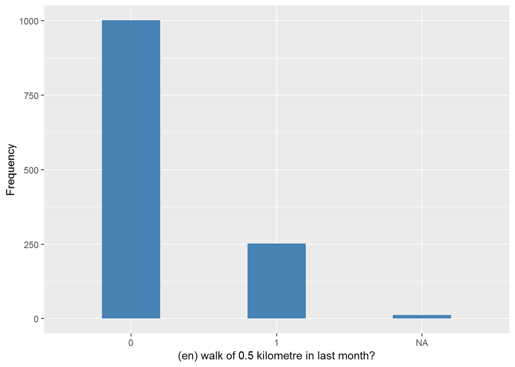

#### 2.11.2.2 Harmonisation algorithm

To compute the harmonize variable from the study-specific variable it has to be recoded as follows:

- `NA into 999`

```r
t1066_ds_PR_w2 <- tibble(id = t1066_PR_w2$id)
t1066_ds_PR_w2$t_walks <- Recode(t1066_PR_w2$f_PWALKANY, "NA = '999' ")
t1066_ds_PR_w2$t_walks <- labelled(t1066_ds_PR_w2$t_walks, labels = c(Missing = 999,
    Do_not_know = 998, Refuse = 997, Not_applicable = 996, Does_not_answer = 995,
    Not_attempt_not_done = 994, Disable_to_measure = 993, Impute = 992, CAPI_interviewer_error = 991))
```

#### 2.11.2.3 Statistical description of the new harmonised variable

Walking at least 10 min or equivalent by 0.5km during the last 1-2 weeks

| Sample size | Missing values |
| --- | --- |
| 1265 | 12 |

Category

|  | 0 | 1 |
| --- | --- | --- |
| Frequency | 1001.00 | 252.00 |
| Percentage | 79.13 | 19.92 |

Type of missing

|  | 991 | 992 | 993 | 994 | 995 | 996 | 997 | 998 | 999 | NA |
| --- | --- | --- | --- | --- | --- | --- | --- | --- | --- | --- |
| Frequency | 0 | 0 | 0 | 0 | 0 | 0 | 0 | 0 | 12.00 | 0 |
| Percentage | 0 | 0 | 0 | 0 | 0 | 0 | 0 | 0 | 0.95 | 0 |

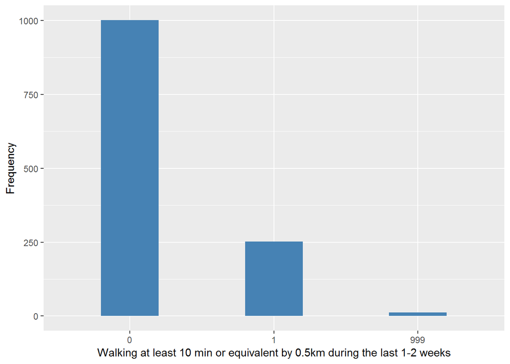

#### 2.11.2.4 Validation

|  | 0->0 | 1->1 | NA->999 |
| --- | --- | --- | --- |
| BeforeH | 1001 | 252 | 12 |
| AfterH | 1001 | 252 | 12 |

## 2.12 Descriptive statistics of the harmonised variable accross populations and waves

Percentages of categories in each harmonised variable:

```r
lb.hds <- list(cuba_w1 = t1066_ds_cuba_w1, india_w1 = t1066_ds_india_w1, UCh_w1 = t1066_ds_UCh_w1,
    RCh_w1 = t1066_ds_RCh_w1, DR_w1 = t1066_ds_DR_w1, Ven_w1 = t1066_ds_Ven_w1,
    UP_w1 = t1066_ds_UP_w1, RP_w1 = t1066_ds_RP_w1, UM_w1 = t1066_ds_UM_w1,
    RM_w1 = t1066_ds_RM_w1, PR_w1 = t1066_ds_PR_w1)

lf.hds <- list(cuba_w2 = t1066_ds_cuba_w2, UCh_w2 = t1066_ds_UCh_w2, RCh_w2 = t1066_ds_RCh_w2,
    DR_w2 = t1066_ds_DR_w2, Ven_w2 = t1066_ds_Ven_w2, UP_w2 = t1066_ds_UP_w2,
    RP_w2 = t1066_ds_RP_w2, UM_w2 = t1066_ds_UM_w2, RM_w2 = t1066_ds_RM_w2,
    PR_w2 = t1066_ds_PR_w2)

# l.hds <- list(cuba_w1 = t1066_ds_cuba_w1, cuba_w2 = t1066_ds_cuba_w2,
# india_w1 = t1066_ds_india_w1, india_w2 = t1066_ds_india_w2, UCh_w1 =
# t1066_ds_UCh_w1, UCh_w2 = t1066_ds_UCh_w2, RCh_w1 = t1066_ds_RCh_w1,
# RCh_w2 = t1066_ds_RCh_w2, DR_w1 = t1066_ds_DR_w1, DR_w2 = t1066_ds_DR_w2,
# Ven_w1 = t1066_ds_Ven_w1, Ven_w2 = t1066_ds_Ven_w2, UP_w1 =
# t1066_ds_UP_w1, UP_w2 = t1066_ds_UP_w2, RP_w1 = t1066_ds_RP_w1, RP_w2 =
# t1066_ds_RP_w2, UM_w1 = t1066_ds_UM_w1, UM_w2 = t1066_ds_UM_w2, RM_w1 =
# t1066_ds_RM_w1, RM_w2 = t1066_ds_RM_w2, PR_w1 = t1066_ds_PR_w1, PR_w2 =
# t1066_ds_PR_w2)

for (name in names(lb.hds)) {
    aux_object <- lb.hds[[name]]
    label(lb.hds[[name]][[2]]) <- label(aux_object[[2]]) <- ds_label  # Text value assigned at the DS description, at the top
    lb.hds[[name]][[2]] <- labelled(lb.hds[[name]][[2]], labels = cat_label)
    aux_object[[2]] <- car::recode(aux_object[[2]], "miss_values_vector=NA")
    aux_object[[2]] <- labelled(aux_object[[2]], labels = cat_label[1:2])
    m_name <- paste0("t1066_m_ds_", name)
    assign(m_name, aux_object)
    rm(aux_object)
}

for (name in names(lf.hds)) {
    aux_object <- lf.hds[[name]]
    label(lf.hds[[name]][[2]]) <- label(aux_object[[2]]) <- ds_label  # Text value assigned at the DS description, at the top
    lf.hds[[name]][[2]] <- labelled(lf.hds[[name]][[2]], labels = cat_label)
    aux_object[[2]] <- car::recode(aux_object[[2]], "miss_values_vector=NA")
    aux_object[[2]] <- labelled(aux_object[[2]], labels = cat_label[1:2])
    m_name <- paste0("t1066_m_ds_", name)
    assign(m_name, aux_object)
    rm(aux_object)
}

tb.hds <- frq(lb.hds[[1]][2])[[1]][, c(1, 2)]
for (i in seq_along(lb.hds)) {
    tb.hds[2 + i] <- frq(lb.hds[[i]][2])[[1]][, 4]
}
tb.hds[13, ] <- c("n", "sample size", length(lb.hds[[1]][[2]]), length(lb.hds[[2]][[2]]),
    length(lb.hds[[3]][[2]]), length(lb.hds[[4]][[2]]), length(lb.hds[[5]][[2]]),
    length(lb.hds[[6]][[2]]), length(lb.hds[[7]][[2]]), length(lb.hds[[8]][[2]]),
    length(lb.hds[[9]][[2]]), length(lb.hds[[10]][[2]]), length(lb.hds[[11]][[2]]))
names(tb.hds) <- c("val", "label", "cuba_w1", "india_w1", "UCh_w1", "RCh_w1",
    "DR_w1", "Ven_w1", "UP_w1", "RP_w1", "UM_w1", "RM_w1", "PR_w1")
kable(tb.hds)
```

| val | label | cuba_w1 | india_w1 | UCh_w1 | RCh_w1 | DR_w1 | Ven_w1 | UP_w1 | RP_w1 | UM_w1 | RM_w1 | PR_w1 |
| --- | --- | --- | --- | --- | --- | --- | --- | --- | --- | --- | --- | --- |
| 0 | No | 33.81 | 17.81 | 18.02 | 38.32 | 37.05 | 27.94 | 49.53 | 39.67 | 38.19 | 35 | 67.25 |
| 1 | Yes | 65.84 | 81.79 | 81.98 | 61.18 | 62.36 | 68.5 | 49.89 | 59.96 | 61.12 | 63.4 | 32.3 |
| 991 | CAPI interviewer error | 0 | 0 | 0 | 0 | 0 | 0 | 0 | 0 | 0 | 0 | 0 |
| 992 | Impute | 0 | 0 | 0 | 0 | 0 | 0 | 0 | 0 | 0 | 0 | 0 |
| 993 | Disable to measure | 0 | 0 | 0 | 0 | 0 | 0 | 0 | 0 | 0 | 0 | 0 |
| 994 | Not attempt not done | 0 | 0 | 0 | 0 | 0 | 0 | 0 | 0 | 0 | 0 | 0 |
| 995 | Does not answer | 0 | 0 | 0 | 0 | 0 | 0 | 0 | 0 | 0 | 0 | 0 |
| 996 | Not applicable | 0 | 0 | 0 | 0 | 0 | 0 | 0 | 0 | 0 | 0 | 0 |
| 997 | Refuse | 0 | 0 | 0 | 0 | 0 | 0 | 0 | 0 | 0 | 0 | 0 |
| 998 | Do not know | 0 | 0 | 0 | 0 | 0 | 0 | 0 | 0 | 0 | 0 | 0 |
| 999 | Missing | 0.36 | 0.4 | 0 | 0.5 | 0.6 | 3.56 | 0.58 | 0.36 | 0.7 | 1.6 | 0.45 |
| NA | NA | 0 | 0 | 0 | 0 | 0 | 0 | 0 | 0 | 0 | 0 | 0 |
| n | sample size | 2813 | 2004 | 1160 | 1002 | 2011 | 1965 | 1381 | 552 | 1003 | 1000 | 2009 |

```r
tf.hds <- frq(lf.hds[[1]][2])[[1]][, c(1, 2)]
for (i in seq_along(lf.hds)) {
    tf.hds[2 + i] <- frq(lf.hds[[i]][2])[[1]][, 4]
}
tf.hds[13, ] <- c("n", "sample size", length(lf.hds[[1]][[2]]), length(lf.hds[[2]][[2]]),
    length(lf.hds[[3]][[2]]), length(lf.hds[[4]][[2]]), length(lf.hds[[5]][[2]]),
    length(lf.hds[[6]][[2]]), length(lf.hds[[7]][[2]]), length(lf.hds[[8]][[2]]),
    length(lf.hds[[9]][[2]]), length(lf.hds[[10]][[2]]))
names(tf.hds) <- c("val", "label", "cuba_w2", "UCh_w2", "RCh_w2", "DR_w2", "Ven_w2",
    "UP_w2", "RP_w2", "UM_w2", "RM_w2", "PR_w2")
kable(tf.hds)
```

| val | label | cuba_w2 | UCh_w2 | RCh_w2 | DR_w2 | Ven_w2 | UP_w2 | RP_w2 | UM_w2 | RM_w2 | PR_w2 |
| --- | --- | --- | --- | --- | --- | --- | --- | --- | --- | --- | --- |
| 0 | No | 42.4 | 21.86 | 26.44 | 46.2 | 36.28 | 54.94 | 64.85 | 41.12 | 37.87 | 79.13 |
| 1 | Yes | 55.56 | 78.14 | 73.56 | 52.88 | 63.09 | 45.06 | 35.15 | 58.48 | 61.71 | 19.92 |
| 991 | CAPI interviewer error | 0 | 0 | 0 | 0 | 0 | 0 | 0 | 0 | 0 | 0 |
| 992 | Impute | 0 | 0 | 0 | 0 | 0 | 0 | 0 | 0 | 0 | 0 |
| 993 | Disable to measure | 0 | 0 | 0 | 0 | 0 | 0 | 0 | 0 | 0 | 0 |
| 994 | Not attempt not done | 0 | 0 | 0 | 0 | 0 | 0 | 0 | 0 | 0 | 0 |
| 995 | Does not answer | 0 | 0 | 0 | 0 | 0 | 0 | 0 | 0 | 0 | 0 |
| 996 | Not applicable | 0 | 0 | 0 | 0 | 0 | 0 | 0 | 0 | 0 | 0 |
| 997 | Refuse | 0 | 0 | 0 | 0 | 0 | 0 | 0 | 0 | 0 | 0 |
| 998 | Do not know | 0 | 0 | 0 | 0 | 0 | 0 | 0 | 0 | 0 | 0 |
| 999 | Missing | 2.04 | 0 | 0 | 0.92 | 0.64 | 0 | 0 | 0.4 | 0.42 | 0.95 |
| NA | NA | 0 | 0 | 0 | 0 | 0 | 0 | 0 | 0 | 0 | 0 |
| n | sample size | 2007 | 741 | 711 | 1197 | 1257 | 890 | 421 | 749 | 713 | 1265 |

# 3 Quality estimation